# Desindustrialización y Especialización Comercial: aproximaciones a los casos de Argentina, Brasil y Perú. (1960 -2018)

Trabajo Final - Diplomatura en R aplicada a la economia | FCE - UBA |

Enzo Montano

2026-10-05

### **Objetivos**:

Evidenciar la reconfiguración de la producción industrial de Argentina, Perú y Brasil, bajo la nueva división internacional del trabajo (NDIT) con su ida a Asia Oriental.

Tratar años de cambio de gestion gubernamental con interrogantes particulares.

### Introducción

A traves del procesamiento de datos, veremos la evolución de la industria en **Argentina, Brasil y Perú**, entre los años 1960 a 2018, poniendo puntos en algunos años de cambio de conducción del gobierno argentino, para cuestionarnos si eso implica un cambio en la politica economica, independientemente del pais analizado.

Y, por ultimo, si los paises señalados como ejemplos de equilibrio economico tienen armonia economica.

### Hiper - industrialización Asiatica | Des - industrialización Americana

En principio, buscaremos aproximarnos a una respuesta, evaluando la **participación del sector industrial** en el PIB nacional, como también su evolución en términos per cápita en años especificos.

- **Fuentes de datos:** Banco Mundial (WDI) para **Argentina, Brasil y Perú** en los años: **1960, 1976, 1983, 1989, 1999, 2001, 2002, 2015, 2018**.
- **Indicadores**: VAB Manufacturero (% del PIB), Empleo Industrial (%) y VAB Manufacturero Real Per Cápita en USD constantes.

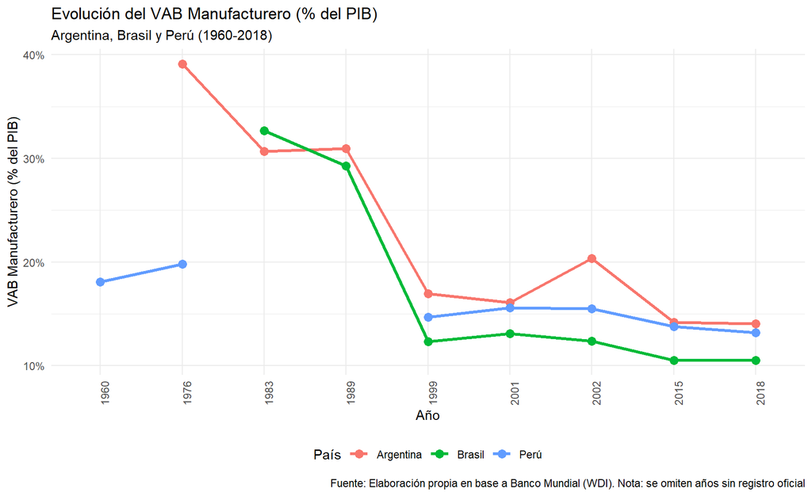

```r
# Definimos parámetros
paises <- c("AR", "BR", "PE")
anios <- c(1960, 1976, 1983, 1989, 1999, 2001, 2002, 2015, 2018)

# Descarga de indicadores desde la API del Banco Mundial

datos_bm_raw <- WDI(
  country = paises,
  indicator = c( "vab_manuf_pib" = "NV.IND.MANF.ZS",
                 "empleo_ind_pct" = "SL.IND.EMPL.ZS",
                 "vab_manuf_usd" = "NV.IND.MANF.KD",
                 "poblacion" = "SP.POP.TOTL" ),
  start = 1960, end = 2018 )

# Procesamiento de datos y cálculo del VAB industrial per cápita

datos_historicos <- datos_bm_raw %>%
  filter(year %in% anios) %>%
  mutate(
    vab_ind_per_capita = vab_manuf_usd / poblacion,
    country = case_when(
      country == "Argentina" ~ "Argentina",
      country == "Brazil" ~ "Brasil",
      country == "Peru" ~ "Perú",
      TRUE ~ country )
    )

# Guardamos la base procesada en la carpeta "bases".

write.csv(datos_historicos,
          "bases/datos_banco_mundial_historico.csv", row.names = FALSE)

# Gráfico 1: VAB Manufacturero (% del PIB)
#teniendo en cuenta falta de datos

datos_historicos_graf1 <-  datos_historicos %>%
  filter(!(country == "Brasil" & year < 1983)) %>%
  mutate(vab_manuf_pib = ifelse(
    vab_manuf_pib == 0, NA, vab_manuf_pib))

#para grafico
grafico_vab_pib <- ggplot(datos_historicos_graf1,
                          aes(x = factor (year),
             y = vab_manuf_pib,
             color = country,
             group = country)) +
  geom_line(size = 1.1, na.rm=FALSE) +
  geom_point(size = 3, na.rm = TRUE) +
  scale_y_continuous(labels = function(x) paste0(x, "%")) + labs(
    title = "Evolución del VAB Manufacturero (% del PIB)",
    subtitle = "Argentina, Brasil y Perú (1960-2018)",
    x = "Año",
    y = "VAB Manufacturero (% del PIB)",
    color = "País",
    caption = "Fuente: Elaboración propia en base a Banco Mundial (WDI). Nota: se omiten años sin registro oficial" ) +
  theme_minimal() +
  theme( axis.text.x =
           element_text(angle = 90, hjust = 1),
         legend.position = "bottom" )

# Guardamos el Gráfico 1 en la carpeta resultados.

ggsave("resultados/grafico_1_vab_pib.png", grafico_vab_pib, width = 8, height = 5)

grafico_vab_pib
```

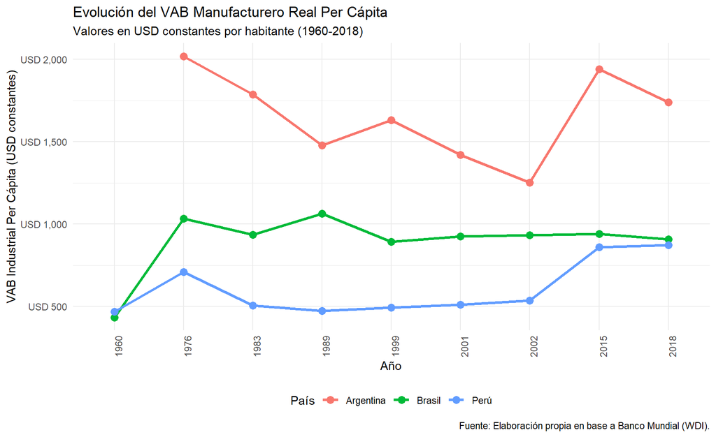

```r
# Gráfico 2: VAB Manufacturero Real Per Cápita (USD constantes).
grafico_vab_per_capita <-
  ggplot(datos_historicos,
         aes(x = factor (year),
             y = vab_ind_per_capita,
             color = country, group = country)) +
  geom_line(size = 1.1) +
  geom_point(size = 3) +
  scale_y_continuous(labels = scales::dollar_format(prefix = "USD ")) +
  labs( title = "Evolución del VAB Manufacturero Real Per Cápita",
        subtitle = "Valores en USD constantes por habitante (1960-2018)",
        x = "Año",
        y = "VAB Industrial Per Cápita (USD constantes)", color = "País",
        caption = "Fuente: Elaboración propia en base a Banco Mundial (WDI)." ) +
  theme_minimal() +
  theme( axis.text.x = element_text(angle = 90, hjust = 1), legend.position = "bottom" )

# Guardamos Gráfico 2.
ggsave("resultados/grafico_2_vab_per_capita.png", grafico_vab_per_capita, width = 8, height = 5)

#chequeamos grafico
grafico_vab_per_capita
```

#### **Análisis de los resultados: trayectoria de desindustrialización.**

El contraste entre la participación del VAB manufacturero en el PIB y el VAB industrial per cápita nos permite caracterizar las **diferentes naturalezas de los procesos** de **desindustrialización**:

Según algunos autores [Herrera Bartis (2021) ; Rowthorn (1986)], en las economias desarrolladas la menor participación del empleo industrial, suele convivir con incrementos continuos en la productividad e ingreso por habitante .

Este proceso, pasar de la producción de bienes a los servicios, es llamado **desindustrialización por madurez**, En los países de América Latina esta dinamica es distinta.

**El caso argentino:** Inicia un quiebre estructural a partir del golpe de Estado de 1976. La fuerte caída relativa del VAB industrial no responde a una transición hacia servicios de alta productividad, sino a un proceso de **desindustrialización prematura y regresiva**, acompañado por el estancamiento y la pérdida neta de capacidad productiva per cápita.

**Brasil y Perú:** Brasil logró consolidar una de las estructuras industriales más diversificadas de la región, sufriendo tensiones de reprimarización en décadas recientes, donde entre los años 1999 y 2015 nos indica una meseta en su capacidad industrial por habitante. Perú, por su parte, mantiene un perfil históricamente primario-extractivo, con niveles de VAB industrial per cápita sensiblemente menores.

### **Complejidad Economica y Especialización Comercial: ¿que le damos al mundo en terminos comerciales?**

Utilizaremos la base de datos de CEPII - BACI, para los años que estan disponibles, seleccionando los que son de nuestro interes: 1995, 2001, 2007, 2011, 2015, 2018 y 2024.

```r
#llamamos librerias
library(tidyverse)
library(writexl)

#seleccionamos los años y paises dentro de la base
paises_cod <- read.csv("bases/country_codes_V202601.csv")
productos_cod <-read.csv("bases/product_codes_HS92_V202601.csv")

anios_baci <- c(1995,2001,2007,2011,2015,2018,2024)
paises_seleccionados <- c("ARG", "BRA", "PER")

#armamos funcion para procesar un año

calcular_baci_anio <- function(anio){
  archivo <- paste0("bases/BACI_HS92_Y", anio, "_V202601.csv")
  if (!file.exists(archivo)){
    message(paste("archivo no encontrado:", archivo))
    return(NULL)
  }

message(paste("Procesando BACI para el año:", anio))

baci_raw <- read.csv(archivo)

# unimos paises e integrar exportaciones por país y producto (X_ci)

comercio <-  baci_raw %>%
  left_join(paises_cod, by = c("i" = "country_code")) %>%
  rename(codigo = country_iso3,
         producto = k, valor = v) %>%
  filter(!is.na(codigo)) %>%
  group_by(codigo, producto) %>%
  summarise(valor = sum(valor, na.rm = TRUE),
            .groups = "drop")

#calcumos VCR
df_vcr <- comercio %>%
  group_by(codigo) %>%
  mutate(expo_total_pais = sum(valor)) %>%
           ungroup() %>%
           group_by(producto) %>%
           mutate(expo_total_prod_mundo=sum(valor)) %>%
           ungroup() %>%
           mutate(
             expo_mundial_total =sum(valor),
             vcr =
               (valor/expo_total_pais)/(expo_total_prod_mundo/expo_mundial_total),
             hay_vcr = ifelse(vcr>1, 1, 0)
           )

#ubicuidad
ubicuidad_prod <- df_vcr %>%
  group_by(producto) %>%
  summarise(ubicuidad_k = sum(hay_vcr), .groups = "drop")

#resumimos para Argentina, Peru y Brasil
resumen <- df_vcr %>%
  filter(codigo %in% paises_seleccionados, hay_vcr == 1) %>%
  left_join(ubicuidad_prod, by = "producto") %>%
  group_by(codigo) %>%
  summarise(
    anio = anio,
    diversidad_kc0 = n_distinct(producto),
    ubicuidad_promedio = mean(ubicuidad_k, na.rm = TRUE),
    .groups = "drop")

return(resumen)
}

#evolucion

evolucion_diversidad <- map_dfr(anios_baci,calcular_baci_anio) %>%
  mutate(
    pais = case_when(
      codigo == "ARG" ~ "Argentina",
      codigo == "BRA" ~ "Brasil",
      codigo == "PER" ~ "Perú"
      )
  )

#exportamos a excel
library(writexl)
write_xlsx(evolucion_diversidad,"resultados/evolucion_diversidad_1995_2024.xlsx")

#graficos de la evolucion de la diversidad exportadora

grafico_diversidad <- ggplot(
  evolucion_diversidad,
  aes(x=anio, y = diversidad_kc0,
      color = pais, group = pais)) +
  geom_line(size=1.2) +
  geom_point(size=3) +
  scale_x_continuous(breaks = anios_baci) +
  labs(
    title = "Evolución de la Diversidad Exportadora (1995 - 2024)",
    subtitle = "cantidad de productos exportados con VCR",
    x="Año",
    y= "Diversidad (numero de productos con VCR > 1)",
    color = "Pais",
    caption = "Fuente: Elaboración propia en base a BACI - CEPI HS92."
  ) +
  theme_minimal()+
  theme(legend.position = "bottom", axis.text.x = element_text(angle = 45, hjust = 1))

ggsave("resultados/grafico_diversidad.png", grafico_diversidad, width = 8, height = 5)

grafico_diversidad
```

[output not shown]

## Conclusiones

A traves de este breve trabajo podemos acercarnos a concluir, con evidencia empirica, que los cambios de gestion de gobierno no siempre implican un cambio de gestion economica, como a veces se afirma, al igual que la estabilidad macroeconomica, no implica armonia economica.

El bienestar y armonia del conjunto de un pais, va acompañado de sus herramentales industriales, para generar trabajo y sueldos acordes a un buen vivir.

**Bibliografía Referenciada:**

**Balassa, B. (1965).** Trade liberalisation and “revealed” comparative advantage.*The Manchester School*, 33(2), 99-123.

**Fernández Franco, S., Paola, I., Terranova, L., & Weksler, G. (2025).** La evolución de la Complejidad Económica en Argentina (2000-2023). *Documentos de Trabajo del IIEP*, N° 101.

**Fumeo, I., & Terranova, L. (2023).** Complejidad económica de las exportaciones argentinas: situación actual y estrategias a futuro. *Documento de Trabajo N° 21*, CEP-XXI.

**García Díaz, F., &a Álvarez, V. (2023).** El desafío exportador de la Argentina: exploración del potencial a corto y mediano plazo. *Documento de Proyecto*, CEPAL.

**Graña, J. M., & Terranova, L. (2022).** Neither mechanical nor premature: Deindustrialization and the New International Division of Labour (1970-2019). *Revista de Historia Industrial*, 31(86), 11-46.

**Herrera Bartis, G. (2021).** Tres caminos de desindustrialización. Un análisis estilizado de los casos del Reino Unido, los Estados Unidos y la Argentina. *H-industri@*, 28, 1-33.

**Lall, S. (2000).** The technological structure and performance of developing country manufactured exports, 1985–1998. *Oxford Development Studies*, 28(3), 337-369.